# CTDPathSim2.0 Vignette

By Banabithi Bose

4/10/2022

# 1 Introduction

CTDPathSim2.0 is a computational tool which utilizes a pathway activity-based approach to compute similarity scores between primary tumor samples and cell lines. CTDPathSim2.0 integrates DNA methylation, gene expression and copy number variation datasets. The package is able to run without copy number variation to produce the results based on previous version of the tool, CTDPathSim1.0. CTDPathSim2.0 has five main computational steps:

Step 1:Computing sample-specific deconvoluted DNA methylation profile

Step 2:Computing sample-specific deconvoluted expression profile

Step 3:Computing sample and cell line-specific differentially expressed (DE) genes and enriched biological pathways

Step 4:Computing sample and cell line-specific differentially methylated (DM) and differentially aberrated (DA) genes

Step 5:Computing sample-cell line pathway activity-based similarity score

```r
library(CTDPathSim2.0)
library(printr)
data("CTDPathSim2")
```

# 2 Example Data Sets

## 2.1 Methylation.Sample

```r
knitr::kable(Methylation.Sample[1:5,1:3], digits = 2, caption = 'Probe-centric DNA methylation values of the tumor samples.')
```

Table 1: Probe-centric DNA methylation values of the tumor samples.

|  | TCGA-OU-A5PI-01A | TCGA-OR-A5K8-01A | TCGA-OR-A5JX-01A |
| --- | --- | --- | --- |
| cg00323915 | 0.93 | 0.55 | 0.32 |
| cg21830221 | 0.87 | 0.90 | 0.63 |
| cg11348106 | 0.91 | 0.55 | 0.77 |
| cg12232731 | 0.82 | 0.30 | 0.55 |
| cg07218880 | 0.16 | 0.13 | 0.07 |

## 2.2 Reference.Methylation.Markers

```r
knitr::kable(Reference.Methylation.Markers[1:5], caption = 'The marker loci (probes) of reference cell types.')
```

Table 2: The marker loci (probes) of reference cell types.

| x |
| --- |
| cg00323915 |
| cg21830221 |
| cg11348106 |
| cg12232731 |
| cg07218880 |

## 2.3 Reference.Methylation.CellTypes

```r
knitr::kable(Reference.Methylation.CellTypes[1:3,1:3], caption = 'R dataframe for the DNA methylation values for the reference cell types and the probes.')
```

Table 3: R dataframe for the DNA methylation values for the reference cell types and the probes.

|  | Neu | NK | Neu_1 |
| --- | --- | --- | --- |
| cg00323915 | 0.8715876 | 0.2367720 | 0.8266145 |
| cg21830221 | 0.8344109 | 0.0714415 | 0.8273859 |
| cg11348106 | 0.8878073 | 0.4177928 | 0.8717599 |

## 2.4 Annotation27K

```r
knitr::kable(Annotation27K[1:3,], caption = 'An R dataframe object with probe, symbol and synonym columns of 27K DNA methylation data annotation.')
```

Table 4: An R dataframe object with probe, symbol and synonym columns of 27K DNA methylation data annotation.

| ID | Symbol | Synonym |
| --- | --- | --- |
| cg00000292 | ATP2A1 | ATP2A; SERCA1; |
| cg00002426 | SLMAP | SLAP; KIAA1601; |
| cg00003994 | MEOX2 | GAX; MOX2; |

## 2.5 Annotation450K

```r
knitr::kable(Annotation450K[c(6,7,10),], caption = 'An R dataframe object with probe ID, UCSC_REFGENE_NAME and UCSC_REFGENE_GROUP columns 450K DNA methylation data annotation.')
```

Table 5: An R dataframe object with probe ID, UCSC_REFGENE_NAME and UCSC_REFGENE_GROUP columns 450K DNA methylation data annotation.

|  | ID | UCSC_REFGENE_NAME | UCSC_REFGENE_GROUP |
| --- | --- | --- | --- |
| 6 | cg00619207 | DENND2D | TSS200 |
| 7 | cg00705730 | NCK2;NCK2 | 5UTR;5UTR |
| 10 | cg00921266 | HOXA3;HOXA3;HOXA3 | 5UTR;5UTR;TSS200 |

## 2.6 Expression.Sample

```r
knitr::kable(Expression.Sample[1:5,1:3], caption = 'An R dataframe for the gene-centric gene expression (RNASeq) values of the tumor samples.')
```

Table 6: An R dataframe for the gene-centric gene expression (RNASeq) values of the tumor samples.

|  | TCGA-OR-A5JT-01A | TCGA-OR-A5K6-01A | TCGA-OR-A5K3-01A |
| --- | --- | --- | --- |
| TSPAN6 | 10.0802526 | 13.3543602 | 10.9596161 |
| TNMD | 0.2315967 | 0.0536225 | 0.0652658 |
| DPM1 | 40.2218416 | 55.3076696 | 30.9633104 |
| SCYL3 | 1.3136879 | 2.2388920 | 0.5801193 |
| C1orf112 | 0.6405102 | 0.4268140 | 0.2524077 |

## 2.7 Expression.CellLine

```r
knitr::kable(Expression.CellLine[1:5,1:3], caption = 'An R dataframe for the gene-centric gene expression (RNASeq) values of the cell lines.')
```

Table 7: An R dataframe for the gene-centric gene expression (RNASeq) values of the cell lines.

|  | LOUNH91_LUNG | T98G_CENTRAL_NERVOUS_SYSTEM | IPC298_SKIN |
| --- | --- | --- | --- |
| TSPAN6 | 10.0802526 | 13.3543602 | 10.9596161 |
| TNMD | 0.2315967 | 0.0536225 | 0.0652658 |
| DPM1 | 40.2218416 | 55.3076696 | 30.9633104 |
| SCYL3 | 1.3136879 | 2.2388920 | 0.5801193 |
| C1orf112 | 0.6405102 | 0.4268140 | 0.2524077 |

## 2.8 CancerGeneList

```r
knitr::kable(CancerGeneList[1:5,], caption = 'An R dataframe object with a column of frequently mutated cancer driver genes.')
```

Table 8: An R dataframe object with a column of frequently mutated cancer driver genes.

| x |
| --- |
| A1CF |
| ABI1 |
| ABL1 |
| ABL2 |
| ACKR3 |

## 2.9 GeneCentric.DNAmethylation.Sample

```r
knitr::kable(GeneCentric.DNAmethylation.Sample[1:5,1:3], caption = 'An R dataframe with gene-centric DNA methylation beta values of bulk tumor samples. Rows are the genes, columns are the tumor samples.')
```

Table 9: An R dataframe with gene-centric DNA methylation beta values of bulk tumor samples Rows are the genes, columns are the tumor samples.

|  | TCGA-OU-A5PI-01A | TCGA-OR-A5K8-01A | TCGA-OR-A5JX-01A |
| --- | --- | --- | --- |
| A1BG | 0.5810136 | 0.2928524 | 0.5154303 |
| A1CF | 0.7602958 | 0.5895629 | 0.7548407 |
| A2BP1 | 0.6226549 | 0.5788986 | 0.3892227 |
| A2LD1 | 0.9217585 | 0.9184202 | 0.9097963 |
| A2M | 0.7231098 | 0.5392000 | 0.5754296 |

## 2.10 GeneCentric.DNAmethylation.CellLine

```r
knitr::kable(GeneCentric.DNAmethylation.CellLine[1:5,1:3], caption = 'An R dataframe with gene-centric DNA methylation beta values of cell lines. Rows are the genes, columns are the cell lines.')
```

Table 10: An R dataframe with gene-centric DNA methylation beta values of cell lines Rows are the genes, columns are the cell lines.

|  | LOUNH91_LUNG | T98G_CENTRAL_NERVOUS_SYSTEM | IPC298_SKIN |
| --- | --- | --- | --- |
| A1BG | 0.5810136 | 0.2928524 | 0.5154303 |
| A1CF | 0.7602958 | 0.5895629 | 0.7548407 |
| A2BP1 | 0.6226549 | 0.5788986 | 0.3892227 |
| A2LD1 | 0.9217585 | 0.9184202 | 0.9097963 |
| A2M | 0.7231098 | 0.5392000 | 0.5754296 |

## 2.11 CNV.CellLine

```r
knitr::kable(CNV.CellLine[1:5,1:3], caption = 'An R dataframe with gene-centric copy number values of cell lines. Rows are the genes, columns are the cell lines.')
```

Table 11: An R dataframe with gene-centric copy number values of cell lines Rows are the genes, columns are the cell lines.

|  | LOUNH91_LUNG | T98G_CENTRAL_NERVOUS_SYSTEM | IPC298_SKIN |
| --- | --- | --- | --- |
| A1BG | 0.0259 | 0.1514 | 0.1511 |
| NAT2 | 0.0325 | 0.0742 | 0.2180 |
| ADA | 0.7455 | 0.5280 | 0.1834 |
| CDH2 | 0.0136 | 0.4032 | 0.5538 |
| AKT3 | 0.0488 | 0.1349 | 0.1940 |

# 3 CTDPathsim2.0 Functions

## 3.1 Step 1: Computing sample-specific deconvoluted methylation profile.

### 3.1.1 Function1: RunDeconvMethylFun

```r
?RunDeconvMethylFun
```

| RunDeconvMethylFun | R Documentation |
| --- | --- |

## Deconvolution of DNA methylation of bulk tumor samples

### Usage

```r
RunDeconvMethylFun(Methylation.Sample, Reference.Methylation.Probes)
```

### Arguments

| `Methylation.Sample` | A R dataframe for the probe-centric DNA methylation values of the tumor samples. |
| --- | --- |
| `Reference.Methylation.Probes` | A vector of the marker loci (probes) based on comparisons of each class of reference against all other samples using t-test. |

### Details

Created By: Banabithi Bose| Date Created: 4/10/2022 | Stage 1 | Function 1 |

### Value

A list of seven items: Estimated DNA methylation profile of constituent cell types, estimated proportions of constituent cell types, iteration number, explained variance, residual sum of squares, Akaike information criterion (AIC), and the residual sum of squares per iteration.

```r
# Running the function
stage1_result_ct <-
  RunDeconvMethylFun(Methylation.Sample,Reference.Methylation.Markers)
```

```r
# Outputs
knitr::kable(stage1_result_ct$methylation[1:5,], caption = 'Estimated DNA methylation profile of constituent cell types.')
```

Table 12: Estimated DNA methylation profile of constituent cell types.

| cg00323915 | 0.1829576 | 0.1606655 | 0.5224483 |
| --- | --- | --- | --- |
| cg21830221 | 0.6576261 | 0.8006104 | 0.9129289 |
| cg11348106 | 0.7750149 | 0.6967357 | 0.8727030 |
| cg12232731 | 0.5502076 | 0.5240273 | 0.6487638 |
| cg07218880 | 0.3673889 | 0.0751444 | 0.5104532 |

```r
knitr::kable(stage1_result_ct$proportions[1:5,], caption = 'Estimated proportions of constituent cell types.')
```

Table 12: Estimated proportions of constituent cell types.

| TCGA-OU-A5PI-01A | 0.00 | 0.31 | 0.69 |
| --- | --- | --- | --- |
| TCGA-OR-A5K8-01A | 0.00 | 0.55 | 0.45 |
| TCGA-OR-A5JX-01A | 0.07 | 0.86 | 0.07 |
| TCGA-OR-A5LT-01A | 0.23 | 0.58 | 0.19 |
| TCGA-PK-A5H9-01A | 0.20 | 0.73 | 0.07 |

### 3.1.2 Function2: PlotDeconvMethylFun

```r
?PlotDeconvMethylFun
```

| PlotDeconvMethylFun | R Documentation |
| --- | --- |

## Correlation plot to show the correlation between the reference cell types and estimated clusters DNA methylation deconvolution

### Description

This function creates a correlation plot to show the correlation between the reference cell types used and estimated clusters after DNA methylation deconvolution. Users can use this plot to choose the appropriate labels for the cell types for the deconvoluted DNA methylation profiles.

### Usage

```r
PlotDeconvMethylFun(
  Methylation.Sample,
  Reference.Methylation.Probes,
  Reference.Methylation.CellTypes,
  stage1_result_ct,
  Reference.CellTypes.Names
)
```

### Arguments

| `Methylation.Sample` | A R dataframe for the DNA methylation values for the samples and the probes. |
| --- | --- |
| `Reference.Methylation.Probes` | A vector of the marker loci (probes) based on comparisons of each class of reference against all other samples using t-test. |
| `Reference.Methylation.CellTypes` | A R dataframe for the DNA methylation values for the reference cell types and the probes. |
| `stage1_result_ct` | The output from RunDeconvMethylFun() |
| `Reference.CellTypes.Names` | A vector of the names of the reference cell types. |

### Details

Created By: Banabithi Bose| Date Created: 4/10/2022 | Stage 1 | Function 2 |

### Value

Correlation Plot.

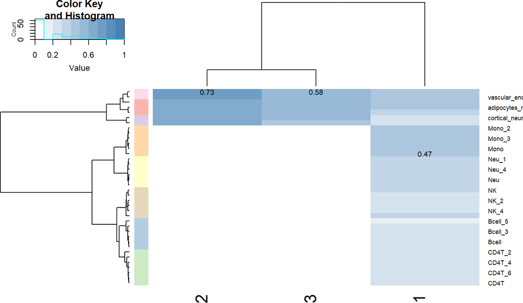

[output not shown]

[output cut: 24 more lines]

[output not shown]

```r
# Running the function
print(
PlotDeconvMethylFun(Methylation.Sample,Reference.Methylation.Markers,Reference.Methylation.CellTypes,stage1_result_ct,Reference.CellTypes.Names)
)
```

```r
dev.off()
```

### 3.1.3 Function3: ProbeToGeneFun

```r
?ProbeToGeneFun
```

| ProbeToGeneFun | R Documentation |
| --- | --- |

## Converting DNA methylation data from probes to genes

### Description

This function converts the DNA methylation data from probe-centric to gene-centric. This function works for both the 450K probe format and 27K probe format.

### Usage

```r
ProbeToGeneFun(
  Methylation.Probe.Annotation,
  Deconv_methylation,
  Annotation.skim
)
```

### Arguments

| `Methylation.Probe.Annotation` | A R dataframe object with ‘probe’, ‘symbol’ and ‘synonym’ columns for 27K or ‘ID’, ‘UCSC_REFGENE_NAME’, ‘UCSC_REFGENE_GROUP’ columns for 450K DNA methylation data according to the convention of the an… |
| --- | --- |
| `Deconv_methylation` | A R dataframe with DNA methylation values for each probe and cell type. |
| `Annotation.skim` | A character string indicating if the user is using either 450K or 27K probes. |

### Details

Created By: Banabithi Bose| Date Created: 4/10/2022 | Stage 1 | Function 3 |

### Value

An R dataframe object with deconvoluted DNA methylation values for each gene in cell types. The rows are the genes and the columns are the cell types. This function labels the columns as V1, V2, V3,….etc.

```r
# Running the function
Deconv_methylation <- stage1_result_ct$methylation
Deconv_meth_gene <-
  ProbeToGeneFun(Annotation450K,Deconv_methylation,"450K")
# Output
knitr::kable(Deconv_meth_gene[1:5,], caption = 'An R dataframe object with deconvoluted DNA methylation values for each gene in cell types. The rows are the genes and the columns are the cell types. This function labels the columns as V1, V2, V3,....etc.')
```

Table 13: An R dataframe object with deconvoluted DNA methylation values for each gene in cell types The rows are the genes and the columns are the cell types. This function labels the columns as V1, V2, V3,….etc.

|  | V1 | V2 | V3 |
| --- | --- | --- | --- |
| ABI3 | 0.8692456 | 0.9318309 | 0.9343204 |
| ADORA2A | 0.4833534 | 0.9693054 | 0.9688003 |
| ANKRD11 | 0.3610563 | 0.8464842 | 0.9703333 |
| BIN2 | 0.5049662 | 0.9823427 | 0.9621157 |
| BLK | 0.2800671 | 0.5299995 | 0.8206106 |

### 3.1.4 Function4: SampleMethylFun

```r
?SampleMethylFun
```

| SampleMethylFun | R Documentation |
| --- | --- |

## Sample-specific deconvoluted DNA methylation profile.

### Description

This function utilizes the estimated proportion of constituent cell types and the estimated gene-centric DNA methylation profile of constituent cell type to compute the sample-specific deconvoluted DNA methylation profile for each tumor sample. Created By: Banabithi Bose| Date Created: 4/10/2022 | Stage 1 | Function 4 |

### Usage

```r
SampleMethylFun(Deconv_meth_gene, Deconv_proportions, CTDDirectory = "~")
```

### Arguments

| `Deconv_meth_gene` | A R dataframe with the deconvoluted DNA methylation values for each gene in constituent cell types. |
| --- | --- |
| `Deconv_proportions` | A R dataframe with the estimated proportions of constituent cell types in samples. |
| `CTDDirectory` | A character string for the file path of the directory for the output to be stored. |

### Value

R dataframes including the deconvoluted DNA methylation profile for each sample in the specified directory. The rows are the genes and the columns are the cell types.This function labels the columns as V1, V2, V3,….etc.

```r
# Running the function
CTDDirectory <- tempdir()
SampleMethylFun(Deconv_meth_gene,Deconv_proportions, CTDDirectory)
```

```r
# Output
load("~/Sample_methylation/TCGA-OR-A5J1-01A.Rda")
knitr::kable(methylation[1:5,], caption = 'Deconvoluted DNA methylation profile of the sample TCGA-OR-A5J1-01A')
```

Table 14: Deconvoluted DNA methylation profile of the sample TCGA-OR-A5J1-01A

|  | V1 | V2 | V3 |
| --- | --- | --- | --- |
| ABI3 | 0.3075042 | 0.0086925 | 0.6166515 |
| ADORA2A | 0.3198708 | 0.0048335 | 0.6394082 |
| ANKRD11 | 0.2793398 | 0.0036106 | 0.6404200 |
| BIN2 | 0.3241731 | 0.0050497 | 0.6349964 |
| BLK | 0.1748998 | 0.0028007 | 0.5416030 |

## 3.2 Step 2: Computing sample-specific deconvoluted expression profile.

### 3.2.1 Function1: RunDeconvExprFun

```r
?RunDeconvExprFun
```

| RunDeconvExprFun | R Documentation |
| --- | --- |

## Deconvolution of gene expression of bulk tumor samples

### Description

This function utilizes the estimated cell proportions from Step 1 as a fixed input and computes an average gene expression profiles of constituent cell types through a constrained least-squares using quadratic programming.

### Usage

```r
RunDeconvExprFun(Expression.Sample, Deconv_proportions)
```

### Arguments

| `Expression.Sample` | A R dataframe for the gene-centric gene expression (RNASeq) values of the tumor samples. |
| --- | --- |
| `Deconv_proportions` | A R dataframe with estimated cell proportions in tumor samples from output of the RunDeconvMethylFun() function. |

### Details

Created By: Banabithi Bose| Date Created: 4/10/2022 | Stage 2 | Function 1 |

### Value

A R dataframe with gene expression values in constituent cell types. The rows are the genes and the columns are the cell types. This function labels the columns as ,1, ,2,,3,….etc.

```r
# Running the function
Deconv_expression<-RunDeconvExprFun(Expression.Sample,Deconv_proportions)
# Output
knitr::kable(Deconv_expression[1:5,], caption = 'An R dataframe object with deconvoluted gene expression values for each gene in cell types. The rows are the genes and the columns are the cell types. This function labels the columns as V1, V2, V3,....etc.')
```

Table 15: An R dataframe object with deconvoluted gene expression values for each gene in cell types The rows are the genes and the columns are the cell types. This function labels the columns as V1, V2, V3,….etc.

| TSPAN6 | 10.2170293 | 7.662672 | 7.4049619 |
| --- | --- | --- | --- |
| TNMD | 0.1067874 | 0.244172 | 0.0321168 |
| DPM1 | 35.6648144 | 25.368440 | 42.1562712 |
| SCYL3 | 1.3917714 | 1.781208 | 1.2404976 |
| C1orf112 | 0.2324402 | 1.249619 | 0.9056265 |

### 3.2.2 Function2: SampleExprFun

```r
?SampleExprFun
```

| SampleExprFun | R Documentation |
| --- | --- |